# Getting Data and Databases - HW

Nneka Okereke

2024-03-05

## Assignment 6

#### is due on **March 8th, 2024**

**Instructions:**

Please turn in the answers to this assignment as a knitted R markdown document.

- For this, don’t forget to comment out all package installations after you install them! You don’t want to keep installing things over and over!

Answers will be graded for correctness, completeness, and how well the instructions are followed.

Turn in your assignment on canvas

```
@ These are the learning objectives associated with each question
```

#### QUESTION 1 (5 pts)

```
@ Students will display that they understand how to obtain data from the SRA.
```

Go to the [SRA website](https://www.ncbi.nlm.nih.gov/sra).

This time, search for an organism of your interest, along with a tissue or condition of your interest. You can further narrow it down to a type of NGS platform (i.e., RNAseq) if you’d like.

Find something that you are interested in and that seems like a good candidate. Don’t get anything too big either.

In your search results, **click on your sample of interest**. You should be pulled to a new page. Here, you will see a bunch of information on your sample. Under **Runs**, go ahead and click on your sample accession number. This will pull you to the SRA browser were you can see **Metadata, Analaysis, Reads, Data Access, and FASTA/FASTQ download tabs.**

Go under FASTA/FASTQ and download the FASTQ file.

Go ahead and put your FASTQ files in a new directory called seq_data. Make sure all file paths are correct!

Now read your file in.

**Organisn of interest**: *Arabidopsis thaliana* **Study**: Histone Deacetylases HD2A and HD2B undergo Feedback Regulation by ABA and Modulate Drought Tolerance via Mediating ABA-induced Transcriptional **(PRJEB62123)**

```r
#if (!require("BiocManager", quietly = TRUE))
#    install.packages("BiocManager")

#BiocManager::install("ShortRead")
library(ShortRead)
# this is just an example of what I did. You will have to modify the path for your specific data.
seq1 <- readFastq("./seq_data/ERR11443657.fastq.gz",pattern=character(0))

# returns sequence information
sread(seq1)
```

```
## DNAStringSet object of length 13977781:
##            width seq
##        [1]   100 CNTTTTCACAGATTGGAGTGTCCAGAACCC...GTATGAGCCTCCGTAATGGCCAGATCGGAA
##        [2]   100 GNTAAGACGGGTCATGAGCTTTGTGTTCTG...ACGGTGAAGGAAGTAGGCTCGAAGCAGAAC
##        [3]   100 GNGATCAAAACCGTAATCTCCAACCAAGGA...AGAGGCCGGTCCGTAGTCACCGTCTTTTTG
##        [4]   100 CNCTGTTAAAAGTTCAGCGTAGTTCTTCTC...ATCGGAAGAGCACACGTCTGAACTCCAGTC
##        [5]   100 GNAAAGTAAAAATCCAACTAACATCGAAAT...ATTGGAGCCACGTCTTGGTCACCTGCAACA
##        ...   ... ...
## [13977777]   100 GGCAGAAGGGTGCTTCTCTAGTGAAGAAAG...CTTAGAGACCAGACTCGATAAGGTAATCGC
## [13977778]   100 CCGGAATACAGGAACGTTGACGGAAAAAAA...CTTTAACAAATTCAAAATTTAAAACATAAA
## [13977779]   100 CTCCGTTCCTAGCCAATAGCTCAGGGAAAA...AACTTCTAGCTCACGGTTCCTGGCGAAGGT
## [13977780]   100 ATGGAGTTGACTTGCAAGCGAGAGAAGGTG...TGGCACGAATATTGGTGGCTGTGACGGAGG
## [13977781]   100 CCAAGTTTTGCTGCTAACACTCGGCCTTGC...ACTCGCTCAGTCTCTGATTCTTCTCGTTCT
```

```r
# returns the Phred quality score
quality(seq1) # Phred-scaled quality score represents how confident we are in the assignment of each base call by the sequencer.
```

```
## class: FastqQuality
## quality:
## BStringSet object of length 13977781:
##            width seq
##        [1]   100 ??????????????????????????????...??????????????????????????????
##        [2]   100 ??????????????????????????????...??????????????????????????????
##        [3]   100 ??????????????????????????????...??????????????????????????????
##        [4]   100 ??????????????????????????????...??????????????????????????????
##        [5]   100 ??????????????????????????????...??????????????????????????????
##        ...   ... ...
## [13977777]   100 ??????????????????????????????...??????????????????????????????
## [13977778]   100 ??????????????????????????????...??????????????????????????????
## [13977779]   100 ??????????????????????????????...??????????????????????????????
## [13977780]   100 ??????????????????????????????...??????????????????????????????
## [13977781]   100 ??????????????????????????????...??????????????????????????????
```

```r
# returns the read ID and length
id(seq1)
```

```
## BStringSet object of length 13977781:
##            width seq
##        [1]    28 ERR11443657.1.1 1 length=100
##        [2]    28 ERR11443657.2.1 2 length=100
##        [3]    28 ERR11443657.3.1 3 length=100
##        [4]    28 ERR11443657.4.1 4 length=100
##        [5]    28 ERR11443657.5.1 5 length=100
##        ...   ... ...
## [13977777]    42 ERR11443657.13977777.1 13977777 length=100
## [13977778]    42 ERR11443657.13977778.1 13977778 length=100
## [13977779]    42 ERR11443657.13977779.1 13977779 length=100
## [13977780]    42 ERR11443657.13977780.1 13977780 length=100
## [13977781]    42 ERR11443657.13977781.1 13977781 length=100
```

go ahead and read in another sample file or two from the same BioProject. You can add your additional code below.

```r
# again these file names are just examples of what i did, you will have to modify the paths.

seq2 <- readFastq("./seq_data/ERR11443679.fastq.gz", pattern=character(0))

# returns sequence information
sread(seq2)
```

```
## DNAStringSet object of length 14025876:
##            width seq
##        [1]   100 TNCGTAACATTCCACTGGTCATTTGCACCT...TAGGGTGAGGCTCTTCCCCACTAGATGAAG
##        [2]   100 GNTCCGACTCTTAACTAAATCCCAAAAGCT...ACAAAACATCCCCCTCTTTGCAACGTGGCA
##        [3]   100 GNGAGGAAGTGTTAGTTGGGCACTTGAGAA...TGGTTTTGATGAAACCCACATTGTTGTTAG
##        [4]   100 GNCGTAAGCTCTAGCCGCTTCGATCGCCGT...GGGTCTCGAATAGATCGGAAGAGCACACGT
##        [5]   100 GNTTGTATCAGAAGCAATCTTGGCAAGACC...ATGTTTGACGCCTTAATATCACGGTGAATG
##        ...   ... ...
## [14025872]   100 ACCGTCCATCGTAGTATCCGGGAGTGTTTC...AACACAAGGAATCCACTTGTTGCGGAGAAG
## [14025873]   100 TGATCGGTTCTGTGCAACGGTCTTCTTGAG...TCAGAAAGCTGCTTCAGCTGCTCATCCGAA
## [14025874]   100 TTTTGAAAGAAATCAATCCATAAATATAGT...AATATTAGAAACAAATAACAAAAAGCTCAT
## [14025875]   100 GGTACAGTTACCGGGGGAACGGGTAGCTTA...CTGGAGGAACGGGTAGCTTGGGGACGGTCA
## [14025876]   100 TCCTGTCATATGTGCTTCCCTTTGAAAATT...GCACTTGCCATGAGCTTCTACCCATGCCGA
```

```r
# returns the Phred quality score
quality(seq2)
```

```
## class: FastqQuality
## quality:
## BStringSet object of length 14025876:
##            width seq
##        [1]   100 ??????????????????????????????...??????????????????????????????
##        [2]   100 ??????????????????????????????...??????????????????????????????
##        [3]   100 ??????????????????????????????...??????????????????????????????
##        [4]   100 ??????????????????????????????...??????????????????????????????
##        [5]   100 ??????????????????????????????...??????????????????????????????
##        ...   ... ...
## [14025872]   100 ??????????????????????????????...??????????????????????????????
## [14025873]   100 ??????????????????????????????...??????????????????????????????
## [14025874]   100 ??????????????????????????????...??????????????????????????????
## [14025875]   100 ??????????????????????????????...??????????????????????????????
## [14025876]   100 ??????????????????????????????...??????????????????????????????
```

```r
# returns the read ID and length
id(seq2)
```

```
## BStringSet object of length 14025876:
##            width seq
##        [1]    28 ERR11443679.1.1 1 length=100
##        [2]    28 ERR11443679.2.1 2 length=100
##        [3]    28 ERR11443679.3.1 3 length=100
##        [4]    28 ERR11443679.4.1 4 length=100
##        [5]    28 ERR11443679.5.1 5 length=100
##        ...   ... ...
## [14025872]    42 ERR11443679.14025872.1 14025872 length=100
## [14025873]    42 ERR11443679.14025873.1 14025873 length=100
## [14025874]    42 ERR11443679.14025874.1 14025874 length=100
## [14025875]    42 ERR11443679.14025875.1 14025875 length=100
## [14025876]    42 ERR11443679.14025876.1 14025876 length=100
```

#### QUESTION 2 (5 pts)

```
@ Students will do some basic analysis on their downloaded FASTQ file(s)
```

Using the samples you read in above, lets try out some more of shortread’s functions to interrogate the data.

```r
head(seq1)
```

```
## class: ShortReadQ
## length: 6 reads; width: 100 cycles
```

```r
head(seq2)
```

```
## class: ShortReadQ
## length: 6 reads; width: 100 cycles
```

```r
summary(seq1)
```

```
##     Length      Class       Mode
##   13977781 ShortReadQ         S4
```

```r
summary(seq2)
```

```
##     Length      Class       Mode
##   14025876 ShortReadQ         S4
```

```r
# Performs qualtiy assessment no short reads

qa_data <- qa("./seq_data/", pattern=character(0), type="fastq") # this will output some information about your data
print(qa_data)
```

```
## class: FastqQA(10)
## QA elements (access with qa[["elt"]]):
##   readCounts: data.frame(2 3)
##   baseCalls: data.frame(2 5)
##   readQualityScore: data.frame(1024 4)
##   baseQuality: data.frame(190 3)
##   alignQuality: data.frame(2 3)
##   frequentSequences: data.frame(100 4)
##   sequenceDistribution: data.frame(267 4)
##   perCycle: list(2)
##     baseCall: data.frame(885 4)
##     quality: data.frame(200 5)
##   perTile: list(2)
##     readCounts: data.frame(0 4)
##     medianReadQualityScore: data.frame(0 4)
##   adapterContamination: data.frame(2 1)
```

```r
report(qa_data, dest = ".", type = "html")#exports a quality report
```

```
## [1] "./index.html"
```

```r
x <- qa_data@.srlist # stores qa_data in an R accessible format
x$adapterContamination
```

```
##                      contamination
## ERR11443657.fastq.gz            NA
## ERR11443679.fastq.gz            NA
```

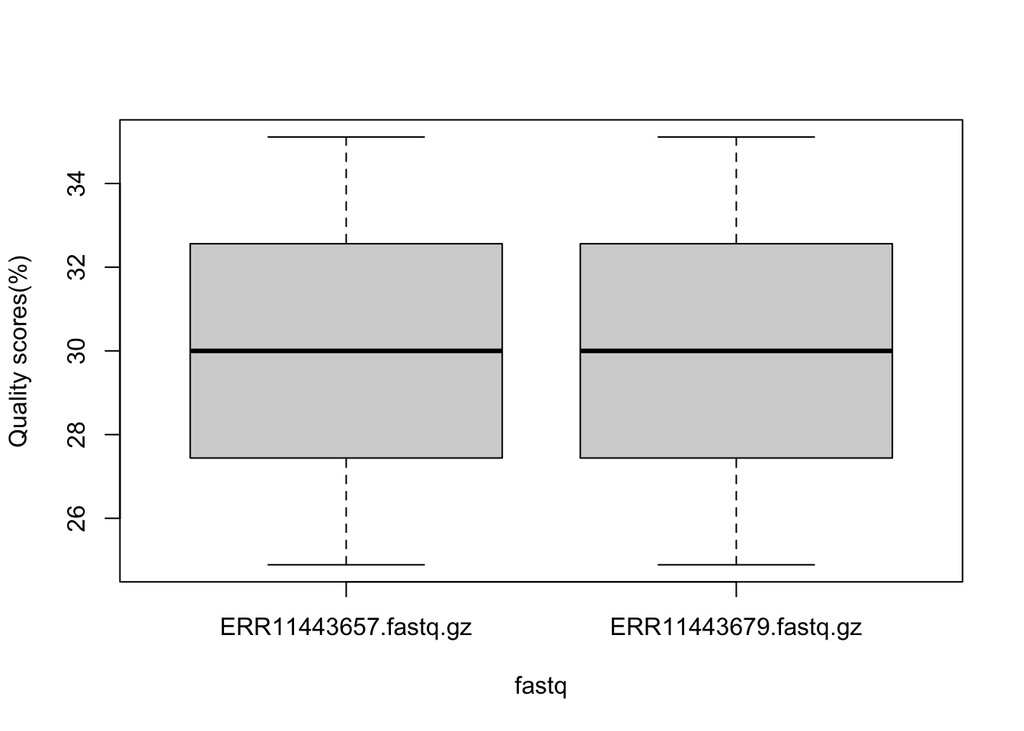

```r
q <- x$readQualityScore #create a dataframe
boxplot(q$quality ~ q$lane, xlab = "fastq", ylab = "Quality scores(%)")
```

Are there any interesting things about your data files that you see?

[output not shown]

We are pretty limited by what we can do not together and within the scope of the class, so we wont delve deeper into the other shortread functions. But go ahead and check them out.

There are other packages like shortread including “Rqc”.

[Rqc](https://www.rdocumentation.org/packages/Rqc/versions/1.6.2) is an optimized tool designed for quality control and assessment of high-throughput sequencing data. It performs parallel processing of entire files and produces a report which contains a set of high-resolution graphics.

#### QUESTION 3 (5 pts)

```
@ Students will gain an understanding of the different types of databases out there, how they differ, and what they offer.
```

Pick one **primary database** that you think could be relevant to your research or interests and describe what data you could obtain from there that would help you moving forward.

Now do the same with one **secondary database** type.

Finally, do the same for one **specialized database** type.

```
Place your responses here:
**primary database** SRA (https://www.ncbi.nlm.nih.gov/sra); I will be using the SRA database, primarily for the submission and download of raw sequence reads.

**secondary database** Phytozome(https://phytozome-next.jgi.doe.gov/); this is a Comparative Genomics platform that provide plant scientists, a hub for accessing, visualizing and analyzing JGI-sequenced plant genomes, as well as selected genomes and datasets that have been sequenced elsewhere. For my research, i will be using this database for identifying gene orthologues for my specific plant of interestst e.g Sorghum and Wheat

**specialized database** Ensembl Plants (http://plants.ensembl.org) is an integrative resource for visualizing, mining, and analyzing plant genomic data.It has a variant effect detector analyse variants (alleles) and predict the functional consequences of known and unknown variants. Its HMMER function enables the quick search of our genomes for protein sequences.
```

#### QUESTION 4 (5 pts)

```
@ Students will learn about a specific R function of their choice, and impliment an example of its usage.
```

Choose an R function you think is interesting and would like to learn more about. Also mention the R package it can be found in.

*Function: read.vcfR; Package: vcfR*

Describe what the function does or how it can be used.

*This function, reads into R variant calling format (vcf) files. The package vcfR can then be used for wrangling these files including converting to other file formats that can be used for downstream analysis in other R packages or bioinformatics softwares.*

Give a functional example of its use. I want to try it too.

```r
install.packages("vcfR")
```

```
## Error in contrib.url(repos, "source"): trying to use CRAN without setting a mirror
```

```r
library(vcfR)
#using vcfR dataset "vcfR_test
data(vcfR_test)
vcfR_test
```

```
## ***** Object of Class vcfR *****
## 3 samples
## 1 CHROMs
## 5 variants
## Object size: 0 Mb
## 0 percent missing data
## *****        *****         *****
```

```r
head(vcfR_test)
```

```
## [1] "***** Object of class 'vcfR' *****"
## [1] "***** Meta section *****"
## [1] "##fileformat=VCFv4.3"
## [1] "##fileDate=20090805"
## [1] "##source=myImputationProgramV3.1"
## [1] "##reference=file:///seq/references/1000GenomesPilot-NCBI36.fasta"
## [1] "##contig=<ID=20,length=62435964,assembly=B36,md5=f126cdf8a6e0c7f379d [Truncated]"
## [1] "##phasing=partial"
## [1] "First 6 rows."
## [1]
## [1] "***** Fixed section *****"
##      CHROM POS       ID          REF   ALT      QUAL FILTER
## [1,] "20"  "14370"   "rs6054257" "G"   "A"      "29" "PASS"
## [2,] "20"  "17330"   NA          "T"   "A"      "3"  "q10"
## [3,] "20"  "1110696" "rs6040355" "A"   "G,T"    "67" "PASS"
## [4,] "20"  "1230237" NA          "T"   NA       "47" "PASS"
## [5,] "20"  "1234567" "microsat1" "GTC" "G,GTCT" "50" "PASS"
## [1]
## [1] "***** Genotype section *****"
##      FORMAT        NA00001          NA00002          NA00003
## [1,] "GT:GQ:DP:HQ" "0|0:48:1:51,51" "1|0:48:8:51,51" "1/1:43:5:.,."
## [2,] "GT:GQ:DP:HQ" "0|0:49:3:58,50" "0|1:3:5:65,3"   "0/0:41:3"
## [3,] "GT:GQ:DP:HQ" "1|2:21:6:23,27" "2|1:2:0:18,2"   "2/2:35:4"
## [4,] "GT:GQ:DP:HQ" "0|0:54:7:56,60" "0|0:48:4:51,51" "0/0:61:2"
## [5,] "GT:GQ:DP"    "0/1:35:4"       "0/2:17:2"       "1/1:40:3"
## [1]
## [1] "Unique GT formats:"
## [1] "GT:GQ:DP:HQ" "GT:GQ:DP"
## [1]
```

```r
# CRAN requires developers to us a tempdir when writing to the filesystem.
# You may want to implement this example elsewhere.
orig_dir <- getwd()
temp_dir <- tempdir()
setwd( temp_dir )
write.vcf( vcfR_test, file = "vcfR_test.vcf.gz" )
vcf <- read.vcfR( file = "vcfR_test.vcf.gz", verbose = FALSE )
vcf
```

```
## ***** Object of Class vcfR *****
## 3 samples
## 1 CHROMs
## 5 variants
## Object size: 0 Mb
## 0 percent missing data
## *****        *****         *****
```

Also provide a link to some documentation describing this function. The **NAME** notation is used for creating a hyperlink. You can provide the link below by filling in the syntax:

[vcfR](https://cran.r-project.org/web/packages/vcfR/index.html)